# IODS course project

Antti Salopuro

# About the project

## Course aims

This course, Introduction to Open Data Science, will teach me how to utilize the open data in data science projects. I will learn how to scrap, wrangle and analyse the data and how to collaborate with other people using tools such as Github and R studio.

My Github repository can be found at https://github.com/salopant/IODS-project

# Week 1 results

This week I have been able to install the R-studio and Git desktop tool. I already had my own Github account. I managed to fork the given Github repository and clone it on my own laptop. I have made some changes on the files cloned (with R-studio) and I also generated a public web page in github that will later be my learning diary (this document).

I learned some basic R - language and how to render the contents added on the R markdown file in the viewer. I had some trouble in getting the R-studio to render my work but I think it was because I did not have an R-studio project created at first.

## Useful links and resources

### Task description and course pages

#### Course page (MOOC)

https://mooc.helsinki.fi/course/view.php?id=158

#### First week task

https://mooc.helsinki.fi/course/view.php?id=158#section-1

#### Data camp exercise

https://www.datacamp.com/courses/r-short-and-sweet

#### Course diary instructions

https://emmakarolina.github.io/instructions/#the_course_diary_web_page

### My results

#### My github repository

https://github.com/salopant/IODS-project

#### My learning diary (this file)

https://salopant.github.io/IODS-project

# Week 2 results

This week I have learned how to do data wrangling with R. Also learned:

- Function select (of library dplyr) applied with function one_of is handy in making a dataframe from a subset of features of original df.
- Function colnames gives me a pointer to the column names.
- Function filter can be applied to filtering those rows of dataframe that fulfill the given criteria

-ggplot with aes mappings is also useful: ggplot(learning2014, aes(col = gender, size = age, x = attitude, y = points))

- pairs draws an array of scatter plots

I also refreshed my knowledge of linear regression analysis and learned something new about model validation. Practical model validation can be done with graphical plots such as plotting the fitted values vs the corresponding residuals (the error between fit and real value), Normal QQ-plot (Theoretical Quantiles vs. Standardized residual) and Residuals vs. leverage.

- diagnostic plot of a linear model with plot & argument which: plot(my_model2, which <- c(1, 2, 5))
- QQ plot reveals information about the normality of the errors
- Constant variance of error plot (fitted vs. residuals) should have no pattern
- Leverage: how much impact a single observation has (e.g. outliers)

## Useful links and resources

Data wrangling cheat sheet: https://www.rstudio.com/wp-content/uploads/2015/02/data-wrangling-cheatsheet.pdf

ggplot2 cheat sheet: https://www.rstudio.com/wp-content/uploads/2016/11/ggplot2-cheatsheet-2.1.pdf

### Link to some videos

Regression analysis

https://player.vimeo.com/video/199820260

Model validation

https://player.vimeo.com/video/199820384

## Task

### Data wrangling part:

https://github.com/salopant/IODS-project/blob/master/data/create_learning2014.R

### Data analysis

#### Exercise data

This data is originally collected by a survey for an international survey of Approaches to Learning by Kimmo Vehkalahti 2014 - 2015. This is a modified version of that data with data of three background questions (age, attitude, points) as such and the data of other questions grouped/compressed (average value of original factors) into three features covering deep, strategic and surface learning.

The total number of respondents is 166, 110 female, 56 male. Number of features is 7.

```r
lrn2014 <- read.csv("./data/learn14.csv")
dim(lrn2014)
```

```
## [1] 166   7
```

An example of typical values of individual respondents to all recorded features can be seen here:

```r
head(lrn2014)
```

```
##   gender Age Attitude     deep  stra     surf Points
## 1      F  53       37 3.583333 3.375 2.583333     25
## 2      M  55       31 2.916667 2.750 3.166667     12
## 3      F  49       25 3.500000 3.625 2.250000     24
## 4      M  53       35 3.500000 3.125 2.250000     10
## 5      M  49       37 3.666667 3.625 2.833333     22
## 6      F  38       38 4.750000 3.625 2.416667     21
```

And a summary of each feature’s variation and means:

```r
summary(lrn2014)
```

```
##  gender       Age           Attitude          deep            stra
##  F:110   Min.   :17.00   Min.   :14.00   Min.   :1.583   Min.   :1.250
##  M: 56   1st Qu.:21.00   1st Qu.:26.00   1st Qu.:3.333   1st Qu.:2.625
##          Median :22.00   Median :32.00   Median :3.667   Median :3.188
##          Mean   :25.51   Mean   :31.43   Mean   :3.680   Mean   :3.121
##          3rd Qu.:27.00   3rd Qu.:37.00   3rd Qu.:4.083   3rd Qu.:3.625
##          Max.   :55.00   Max.   :50.00   Max.   :4.917   Max.   :5.000
##       surf           Points
##  Min.   :1.583   Min.   : 7.00
##  1st Qu.:2.417   1st Qu.:19.00
##  Median :2.833   Median :23.00
##  Mean   :2.787   Mean   :22.72
##  3rd Qu.:3.167   3rd Qu.:27.75
##  Max.   :4.333   Max.   :33.00
```

####Graphical representation of variations of the features: Distribution of age with respect to gender shows that the number of men is lower than that of female and proportionally the difference is significant in class of 1 - 20 years. There are nearly no men of that age, in contrary to females.

With feature of attitude the distribution is much narrower with men, also it is located (mean) in remarkably higher level than that of women.

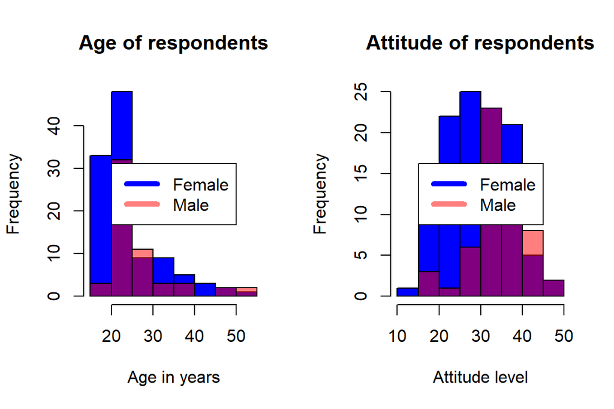

```r
par(mfrow=c(1,2))
colors <- c("blue", adjustcolor("red", alpha.f = 0.5))
hist(lrn2014$Age[lrn2014$gender == "F"], main = "Age of respondents", xlab = "Age in years", col = colors[1])
hist(lrn2014$Age[lrn2014$gender == "M"],col = colors[2], add=TRUE)
legend("center", c("Female", "Male"), col=colors, lwd=5)

colors <- c("blue", adjustcolor("red", alpha.f = 0.5))
hist(lrn2014$Attitude[lrn2014$gender == "F"], main = "Attitude of respondents", xlab = "Attitude level", col = colors[1])
hist(lrn2014$Attitude[lrn2014$gender == "M"],col = colors[2], add=TRUE)
legend("center", c("Female", "Male"), col=colors, lwd=5)
```

From the pairwise scatterplots of the descriptive features of attitude, deep, stra, surf and points we can see that the features deep and surf might correlate negatively. As well, the attitude level and points seem to correlate positively.

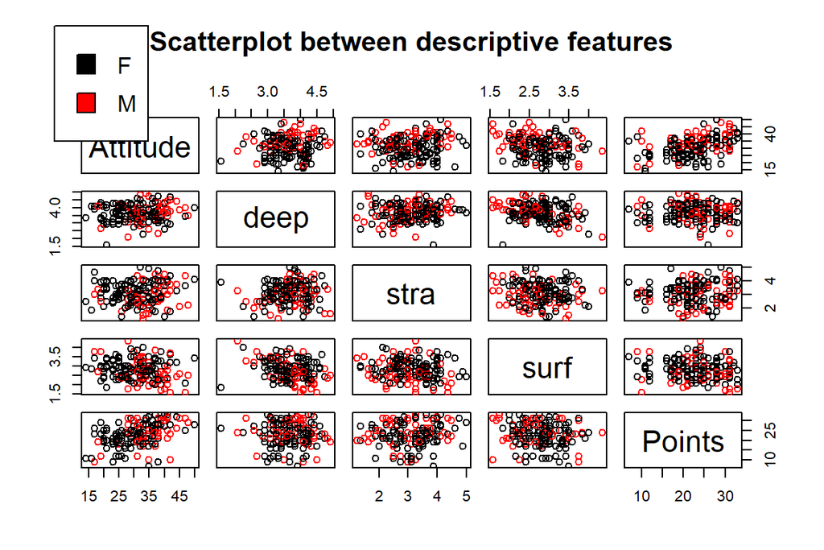

```r
p <- pairs(lrn2014[3:7], col = lrn2014$gender, main = "Scatterplot between descriptive features")
par(xpd=TRUE)
legend(0,1.1, as.vector(unique(lrn2014$gender)), fill=c("black", "red"))
```

```r
#legend("bottomright", fill = unique(iris$Species), legend = c( levels(iris$Species)))
```

The boxplots of this summary plot confirm the difference between the two genders with respect to the attitude (first row, third column). With feature surf there seems to be differnce in the distributions of the two genders implying that females tend to perform better with the questions measuring the surface knowledge factor (6,6). Similar, but smaller, effect can be seen with the factor of strategic knowledge (5,5).

```r
library(GGally)
```

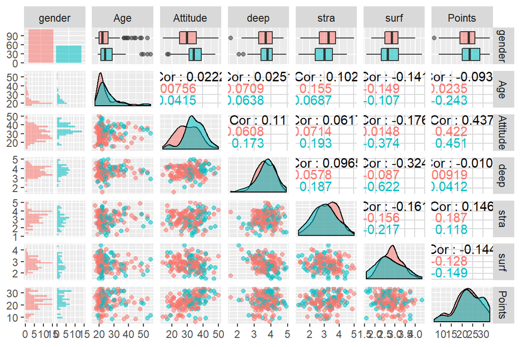

```r
library(ggplot2)

# create a more advanced plot matrix with ggpairs()
ggpairs(lrn2014, mapping = aes(col = gender, alpha = 0.3), lower = list(combo = wrap("facethist", bins = 20)))
```